# Lab 2 - part 2

2022-09-30

#Confidence Intervals

For this practice, we are going to use the “auto-mpg” dataset.

```r
df <- read.csv("auto-mpg.csv")
```

A brief summary:

```r
summary(df)
```

```
##       mpg          cylinders      displacement    horsepower
##  Min.   : 9.00   Min.   :3.000   Min.   : 68.0   Length:398
##  1st Qu.:17.50   1st Qu.:4.000   1st Qu.:104.2   Class :character
##  Median :23.00   Median :4.000   Median :148.5   Mode  :character
##  Mean   :23.51   Mean   :5.455   Mean   :193.4
##  3rd Qu.:29.00   3rd Qu.:8.000   3rd Qu.:262.0
##  Max.   :46.60   Max.   :8.000   Max.   :455.0
##      weight      acceleration     model.year        origin
##  Min.   :1613   Min.   : 8.00   Min.   :70.00   Min.   :1.000
##  1st Qu.:2224   1st Qu.:13.82   1st Qu.:73.00   1st Qu.:1.000
##  Median :2804   Median :15.50   Median :76.00   Median :1.000
##  Mean   :2970   Mean   :15.57   Mean   :76.01   Mean   :1.573
##  3rd Qu.:3608   3rd Qu.:17.18   3rd Qu.:79.00   3rd Qu.:2.000
##  Max.   :5140   Max.   :24.80   Max.   :82.00   Max.   :3.000
##    car.name
##  Length:398
##  Class :character
##  Mode  :character
##
##
##
```

As seen, horsepower should also be numeric. Looking at the df, there are some values containing “?”. We will replace these with Na:

```r
df[df == "?"] <- NA
```

Now we will obtain the statistics summary:

```r
summary(df$horsepower)
```

```
##    Length     Class      Mode
##       398 character character
```

Something weird is still happening. We will need to convert “horsepower” from character to numeric

```r
df$horsepower <- as.numeric(df$horsepower)
```

Now lets check.

```r
summary(df$horsepower)
```

```
##    Min. 1st Qu.  Median    Mean 3rd Qu.    Max.    NA's
##    46.0    75.0    93.5   104.5   126.0   230.0       6
```

Now we have all the information correctly displayed. Now, we have to check which columns look normally distributed:

```r
names(df)
```

```
## [1] "mpg"          "cylinders"    "displacement" "horsepower"   "weight"
## [6] "acceleration" "model.year"   "origin"       "car.name"
```

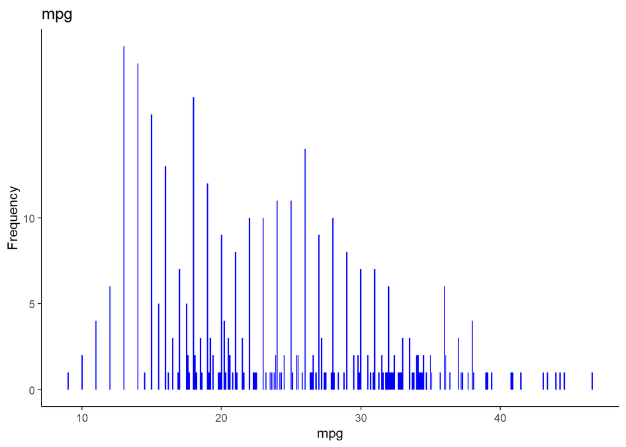

```r
library(ggplot2)
ggplot(df)+ geom_bar(aes(x=mpg), fill="blue") +
  labs(title = "mpg") +
  scale_y_continuous(name="Frequency", breaks=c(0,5,10)) +
  theme_classic()
```

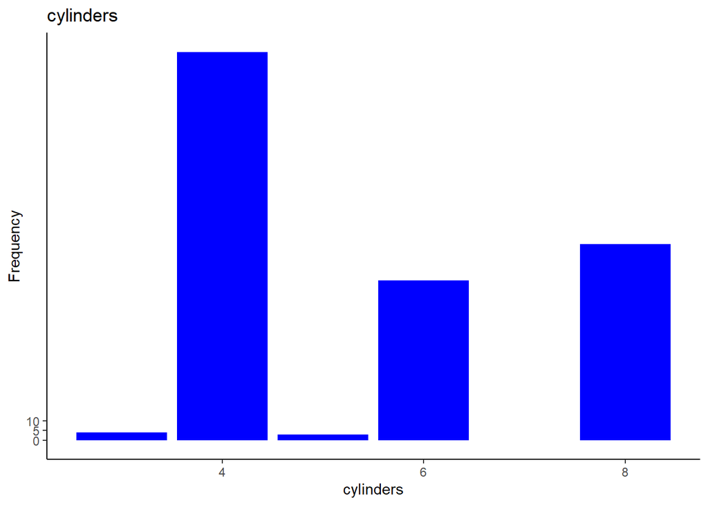

```r
ggplot(df)+ geom_bar(aes(x=cylinders), fill="blue") +
  labs(title = "cylinders") +
  scale_y_continuous(name="Frequency", breaks=c(0,5,10)) +
  theme_classic()
```

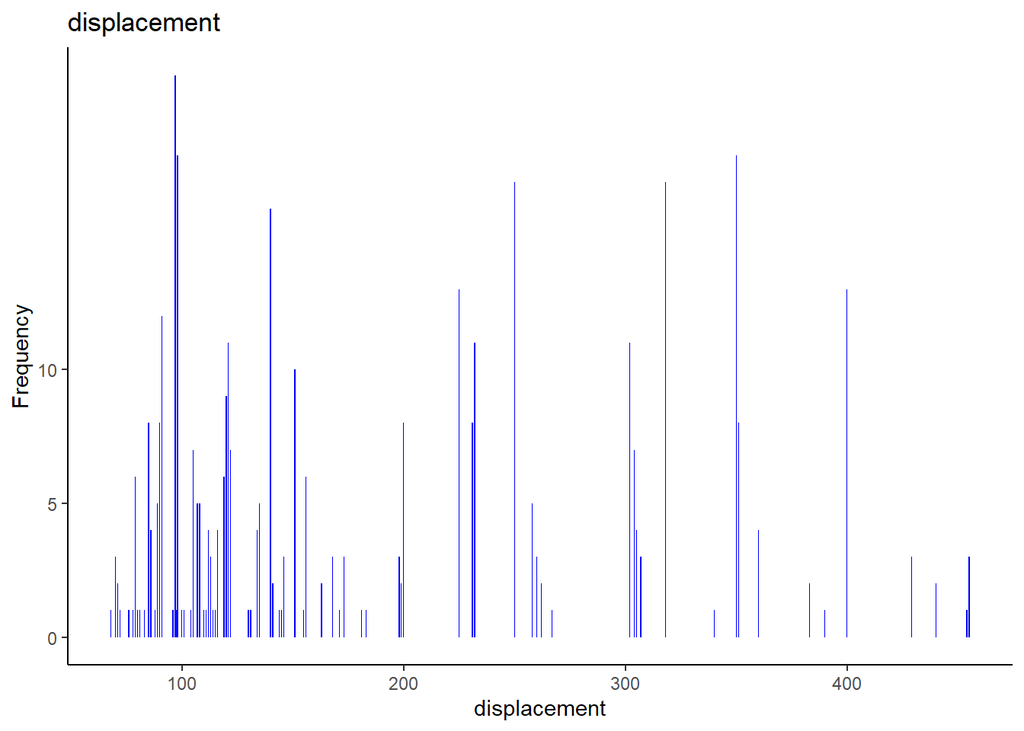

```r
ggplot(df)+ geom_bar(aes(x=displacement), fill="blue") +
  labs(title = "displacement") +
  scale_y_continuous(name="Frequency", breaks=c(0,5,10)) +
  theme_classic()
```

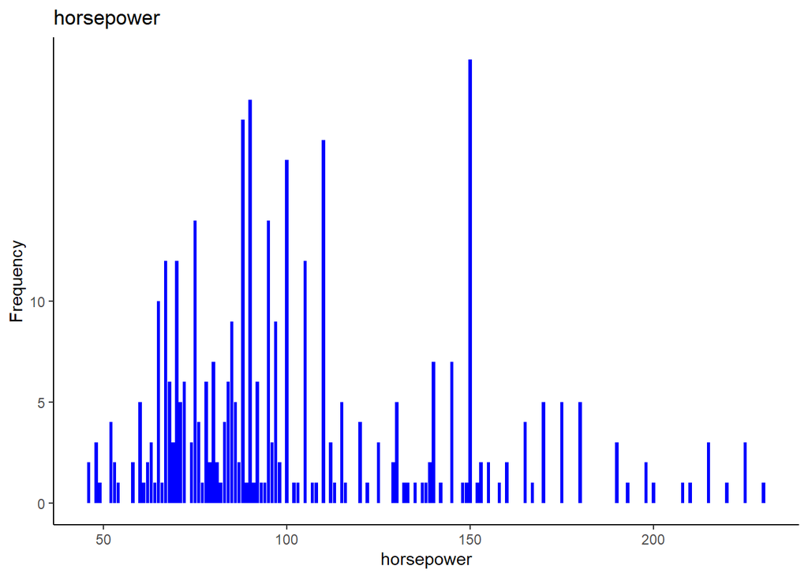

```r
ggplot(df)+ geom_bar(aes(x=horsepower), fill="blue") +
  labs(title = "horsepower") +
  scale_y_continuous(name="Frequency", breaks=c(0,5,10)) +
  theme_classic()
```

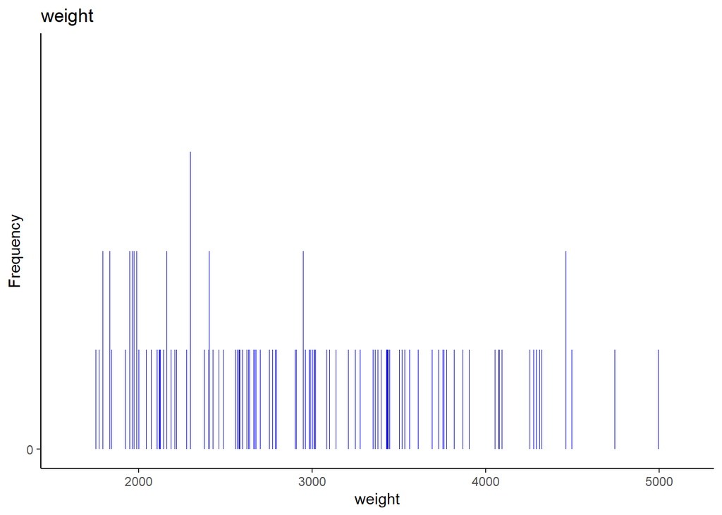

```r
ggplot(df)+ geom_bar(aes(x=weight), fill="blue") +
  labs(title = "weight") +
  scale_y_continuous(name="Frequency", breaks=c(0,5,10)) +
  theme_classic()
```

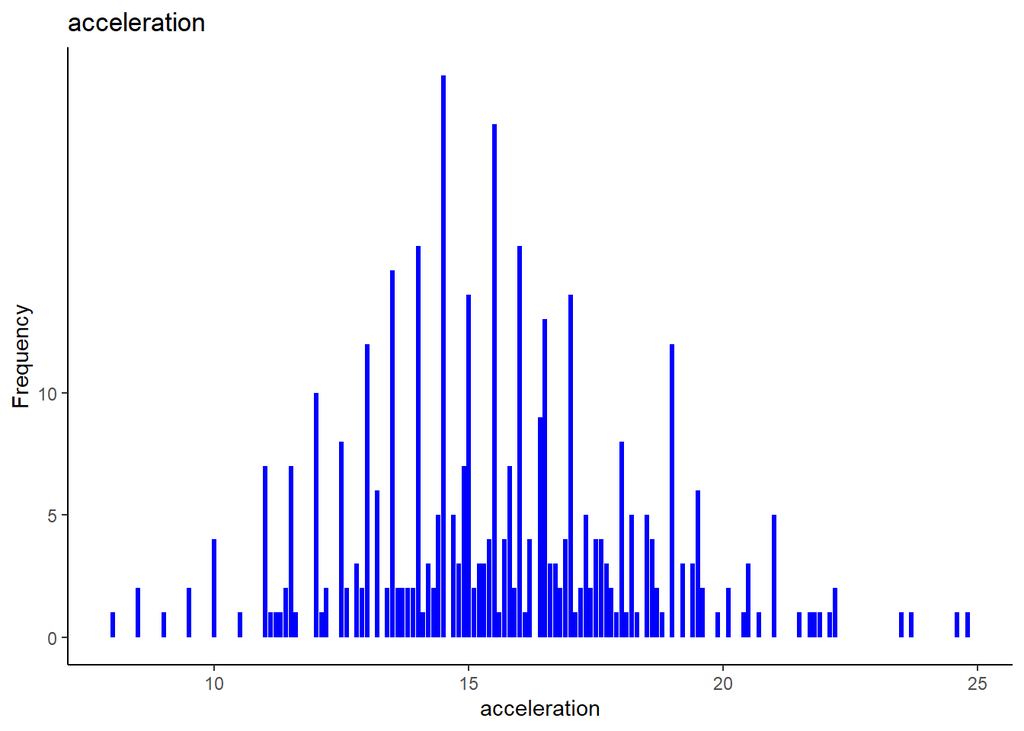

```r
ggplot(df)+ geom_bar(aes(x=acceleration), fill="blue") +
  labs(title = "acceleration") +
  scale_y_continuous(name="Frequency", breaks=c(0,5,10)) +
  theme_classic()
```

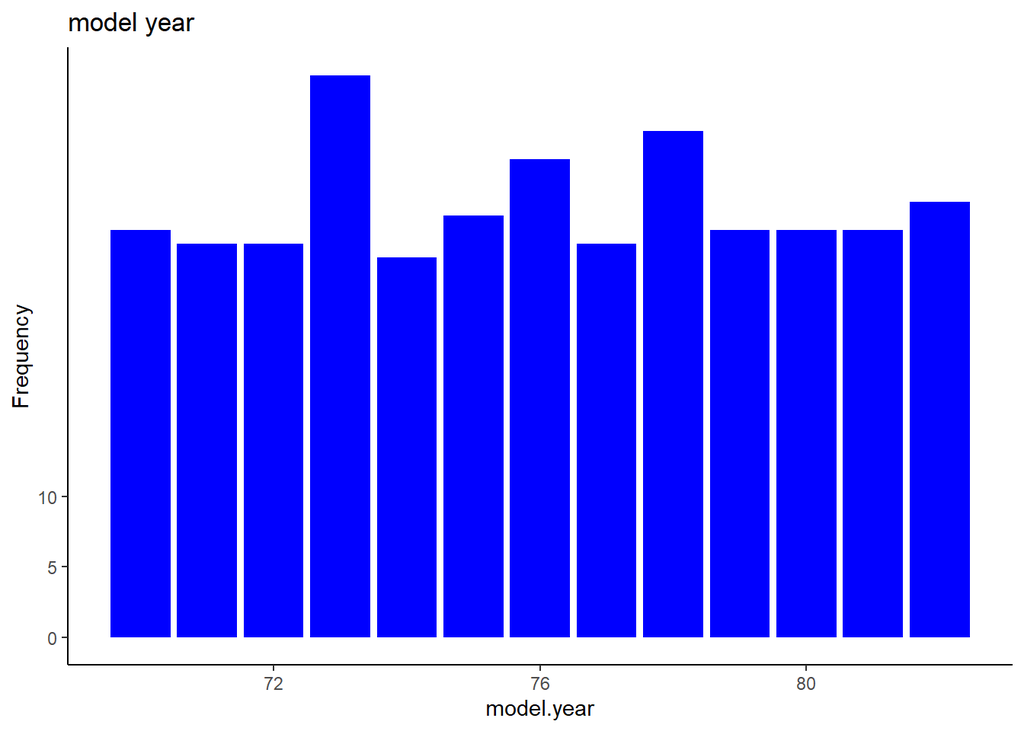

```r
ggplot(df)+ geom_bar(aes(x=model.year), fill="blue") +
  labs(title = "model year") +
  scale_y_continuous(name="Frequency", breaks=c(0,5,10)) +
  theme_classic()
```

As seen, the only variable apparently normally distributed is “acceleration”. Let’s obtain it’s 95% CI:

```r
t.test(df$acceleration)
```

```
##
##  One Sample t-test
##
## data:  df$acceleration
## t = 112.62, df = 397, p-value < 2.2e-16
## alternative hypothesis: true mean is not equal to 0
## 95 percent confidence interval:
##  15.29634 15.83985
## sample estimates:
## mean of x
##  15.56809
```

Now, what proportion of cars are form the 80s?

```r
length(which(df$model.year >= 80))
```

```
## [1] 89
```

```r
89/length(df$model.year)
```

```
## [1] 0.2236181
```

There is an easier method to compute this:

```r
mean(df$model.year >= 80)
```

```
## [1] 0.2236181
```

Thus, the proportion of cars form the 80s is 0.22. Now, we are asked to compute the 90% CI for this proportion:

```r
prop.test(89, length(df$model.year), conf.level = 0.9)
```

```
##
##  1-sample proportions test with continuity correction
##
## data:  89 out of length(df$model.year), null probability 0.5
## X-squared = 120.51, df = 1, p-value < 2.2e-16
## alternative hypothesis: true p is not equal to 0.5
## 90 percent confidence interval:
##  0.1900159 0.2610883
## sample estimates:
##         p
## 0.2236181
```

Although, we know this answer is NOT correct, as the variable “model year” is not normally distributed. For this, we would have to apply a bootstrap:

```r
library(boot)
```

```r
set.seed(1)
func <- function(data,i){
  d <- data[i,]
  c(
    mean(d[,7])
  )
}
```

```r
boot1 <- boot(df,func,R=1000)
boot1
```

```
##
## ORDINARY NONPARAMETRIC BOOTSTRAP
##
##
## Call:
## boot(data = df, statistic = func, R = 1000)
##
##
## Bootstrap Statistics :
##     original       bias    std. error
## t1* 76.01005 -0.008057789   0.1821896
```

```r
boot.ci(boot1,index=1)
```

```
## BOOTSTRAP CONFIDENCE INTERVAL CALCULATIONS
## Based on 1000 bootstrap replicates
##
## CALL :
## boot.ci(boot.out = boot1, index = 1)
##
## Intervals :
## Level      Normal              Basic
## 95%   (75.66, 76.38 )   (75.65, 76.36 )
##
## Level     Percentile            BCa
## 95%   (75.66, 76.37 )   (75.67, 76.38 )
## Calculations and Intervals on Original Scale
```

In this process, we have calculated the 95% CI for the mean of the “model.year” variable. Now, we will calculate the 90% CI for the proportion of cars produced later than the 80s:

```r
set.seed(2)
func1 <- function(data,i){
  d <- data[i,]
  c(
    mean(d[,7] >= 80)
  )
}
```

```r
boot2 <- boot(df,func1,R=1000)
boot2
```

```
##
## ORDINARY NONPARAMETRIC BOOTSTRAP
##
##
## Call:
## boot(data = df, statistic = func1, R = 1000)
##
##
## Bootstrap Statistics :
##      original      bias    std. error
## t1* 0.2236181 0.001386935  0.02038076
```

```r
boot.ci(boot2,index=1, conf = 0.9)
```

```
## BOOTSTRAP CONFIDENCE INTERVAL CALCULATIONS
## Based on 1000 bootstrap replicates
##
## CALL :
## boot.ci(boot.out = boot2, conf = 0.9, index = 1)
##
## Intervals :
## Level      Normal              Basic
## 90%   ( 0.1887,  0.2558 )   ( 0.1884,  0.2563 )
##
## Level     Percentile            BCa
## 90%   ( 0.1910,  0.2588 )   ( 0.1859,  0.2538 )
## Calculations and Intervals on Original Scale
```

So the 90% CI for the proportion of cars made past the 80s is (0.1887, 0.2558).

#Distributions

Assume that among diabetics the fasting blood level of glucose is approximately normally distributed with a mean of 105 mg per 100 ml and a standard deviation of 9mg per 100ml.

To visualize it:

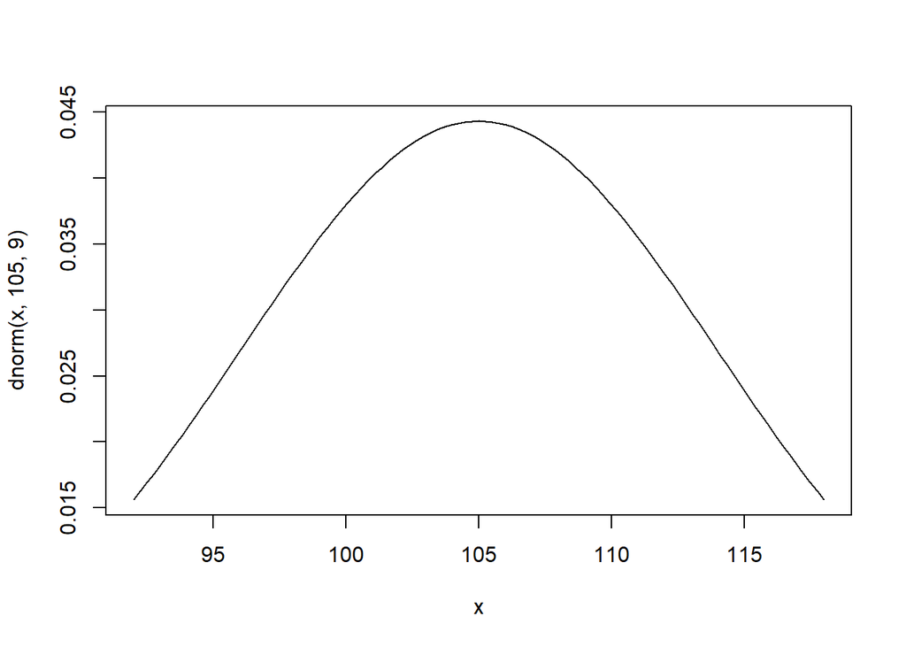

```r
curve(dnorm(x, 105, 9), from=92, to=118)
```

Now, to find the proportion of diabetics that have levels between 90 and 125 mg per 100ml, we can do the following:

```r
level125 <- pnorm(125, 105, 9)
level125
```

```
## [1] 0.9868659
```

```r
level90 <- pnorm(90, 105, 9)
level90
```

```
## [1] 0.04779035
```

```r
answer <- level125-level90
answer
```

```
## [1] 0.9390755
```

Being that the final answer.

Now we want to know what level cuts off the lower 10% of diabetics:

```r
qnorm(0.1,mean=105,sd=9)
```

```
## [1] 93.46604
```

Therefore, 10% of diabetics will have a level of glucose of 93.46 mg or lower.